# F0 CRISPR Screen: Body Size, Adiposity, and Morphology Forest Plots

Standard Length, Normalised Adiposity, Morphology Effect, Droplet Count, and Droplet Area

Minchin Lab

2026-01-30

# Overview

This document presents forest plots for body size, adiposity, and morphology measures from the F0 CRISPR screen:

1. **Standard Length (SL)** - Body size
2. **Normalised Adiposity (TAT/SL2)** - Size-corrected total adipose tissue
3. **Morphology Effect (LMM Intercept)** - Deviation in Feret diameter from expected given total adipose
4. **Droplet Count** - Number of lipid droplets per fish
5. **Mean Droplet Area** - Average lipid droplet size

- SL, Norm Adiposity, Droplet Count, Droplet Area: `value ~ genotype + (1|experiment)`
- Morphology Effect: `log(Feret) ~ log(AreaSum) + genotype + (1|experiment)`

The morphology effect additionally includes size-correction via `log(AreaSum)` to identify hypertrophic (larger droplets than expected) vs hyperplastic (more, smaller droplets) phenotypes.

**Note:** *lamb2* is excluded (single replicate, n=5 mutants).

# Setup

```r
library(dplyr)
library(tidyr)
library(ggplot2)
library(mgcv)
library(lme4)
library(lmerTest)
library(knitr)
library(kableExtra)
```

```r
# Load the SL/TAT/measures data
sl_tat_file <- "CRISPR_screen_data_all_measures_v7.csv"
all_data <- read.csv(sl_tat_file, stringsAsFactors = FALSE)

# Load the morphology data (for Feret/morphology effect analysis)
morph_file <- "CRISPR_screen_data_morphology_v7.csv"
morph_data <- read.csv(morph_file, stringsAsFactors = FALSE)

# Standardise experiment names
standardise_exp_name <- function(exp_name) {
  exp_name <- tolower(trimws(exp_name))
  exp_name <- gsub("^exp([0-9]+)$", "expt\\1", exp_name)
  return(exp_name)
}
all_data$experiment <- sapply(all_data$experiment, standardise_exp_name)
morph_data$experiment <- sapply(morph_data$experiment, standardise_exp_name)

cat("SL/TAT data:", nrow(all_data), "observations\n")
```

```
## SL/TAT data: 7299 observations
```

```r
cat("Morphology data:", nrow(morph_data), "fish\n")
```

```
## Morphology data: 1371 fish
```

```r
cat("Genes:", length(unique(morph_data$gene)), "\n")
```

```
## Genes: 22
```

```r
# Format gene name (italicized for markdown)
format_gene_name <- function(gene, italics = TRUE) {
  if (italics) return(paste0("*", gene, "*"))
  return(gene)
}

# =============================================================================
# LMM-BASED ANALYSIS FOR ALL MEASURES
# =============================================================================
#
# Previously, only morphology used LMM with batch correction. Now ALL measures
# use the same approach for consistency:
#
#   value ~ genotype + (1|experiment)
#
# This accounts for systematic differences between experiments (batch effects)
# and gives more accurate p-values when batch variation exists.
#
# For genes with only 1 experiment, falls back to simple t-test.
# =============================================================================

run_lmm_analysis <- function(data, measure_name) {
  measure_data <- data %>% filter(measure == measure_name)

  genes <- unique(measure_data$gene)
  results_list <- list()

  for (g in genes) {
    gene_data <- measure_data %>%
      filter(gene == g, !is.na(value))

    n_ctrl <- sum(gene_data$genotype == "control")
    n_mut <- sum(gene_data$genotype == "mutant")
    n_expts <- length(unique(gene_data$experiment))

    if (n_ctrl < 3 || n_mut < 3) next

    ctrl_mean <- mean(gene_data$value[gene_data$genotype == "control"])
    mut_mean <- mean(gene_data$value[gene_data$genotype == "mutant"])

    gene_data$genotype <- factor(gene_data$genotype, levels = c("control", "mutant"))

    # Use LMM if >= 2 experiments, otherwise fall back to t-test
    if (n_expts >= 2) {
      tryCatch({
        model <- lmer(value ~ genotype + (1 | experiment), data = gene_data, REML = TRUE)
        coefs <- summary(model)$coefficients

        effect_raw <- as.numeric(coefs["genotypemutant", "Estimate"])
        effect_se <- as.numeric(coefs["genotypemutant", "Std. Error"])
        p_value <- as.numeric(coefs["genotypemutant", "Pr(>|t|)"])

        # Convert to % change relative to control mean
        effect_pct <- effect_raw / ctrl_mean * 100

        results_list[[g]] <- data.frame(
          gene = g,
          n_ctrl = n_ctrl,
          n_mut = n_mut,
          n_expts = n_expts,
          ctrl_mean = ctrl_mean,
          mut_mean = mut_mean,
          effect_pct = effect_pct,
          p_value = p_value,
          method = "LMM",
          stringsAsFactors = FALSE
        )
      }, error = function(e) {
        # If LMM fails, fall back to t-test
        tt <- t.test(gene_data$value[gene_data$genotype == "mutant"],
                     gene_data$value[gene_data$genotype == "control"])
        results_list[[g]] <<- data.frame(
          gene = g,
          n_ctrl = n_ctrl,
          n_mut = n_mut,
          n_expts = n_expts,
          ctrl_mean = ctrl_mean,
          mut_mean = mut_mean,
          effect_pct = (mut_mean - ctrl_mean) / ctrl_mean * 100,
          p_value = tt$p.value,
          method = "t-test (LMM failed)",
          stringsAsFactors = FALSE
        )
      })
    } else {
      # Single experiment - use t-test
      tt <- t.test(gene_data$value[gene_data$genotype == "mutant"],
                   gene_data$value[gene_data$genotype == "control"])
      results_list[[g]] <- data.frame(
        gene = g,
        n_ctrl = n_ctrl,
        n_mut = n_mut,
        n_expts = n_expts,
        ctrl_mean = ctrl_mean,
        mut_mean = mut_mean,
        effect_pct = (mut_mean - ctrl_mean) / ctrl_mean * 100,
        p_value = tt$p.value,
        method = "t-test (single expt)",
        stringsAsFactors = FALSE
      )
    }
  }

  results <- do.call(rbind, results_list)
  rownames(results) <- NULL

  # BH correction
  results$p_adj <- p.adjust(results$p_value, method = "BH")
  results$sig <- results$p_adj < 0.05

  return(results)
}

# Calculate % change from control mean for individual fish (for plotting)
# Centers on control mean so datapoints align with effect estimates
calc_pct_change <- function(data, measure_name) {
  measure_data <- data %>% filter(measure == measure_name)

  ctrl_means <- measure_data %>%
    filter(genotype == "control") %>%
    group_by(gene) %>%
    summarise(ctrl_mean = mean(value, na.rm = TRUE), .groups = "drop")

  measure_data %>%
    left_join(ctrl_means, by = "gene") %>%
    mutate(pct_change = (value - ctrl_mean) / ctrl_mean * 100)
}
```

```r
# =============================================================================
# FOREST PLOT FUNCTION
# =============================================================================
#
# Creates a forest plot showing three levels of data hierarchy:
#
#   1. SMALL GREY DOTS = Individual mutant fish
#      - Each dot is one fish's % change from control mean
#      - Jittered vertically for visibility
#      - Shows the full distribution of individual variation
#
#   2. MEDIUM GREY CIRCLES = Experiment means
#      - Mean of mutant fish within each experiment/replicate
#      - Shows consistency across biological replicates
#      - Should bracket the overall gene mean if data is consistent
#
#   3. BLACK DIAMOND = Gene mean (overall effect)
#      - For simple measures (SL, adiposity): mean % change vs controls
#      - For morphology: LMM intercept coefficient (batch-corrected)
#      - The primary statistic reported in tables
#
# Visual interpretation:
#   - If circles cluster tightly around diamond = consistent across replicates
#   - If circles spread widely = high batch-to-batch variation
#   - If dots spread widely = high fish-to-fish variation within batches
# =============================================================================

create_forest_plot <- function(plot_data, expt_means, gene_stats,
                               title, xlab, gene_order) {

  # Set factor levels for ordering (genes ordered by effect size)
  plot_data$gene <- factor(plot_data$gene, levels = gene_order)
  expt_means$gene <- factor(expt_means$gene, levels = gene_order)
  gene_stats$gene <- factor(gene_stats$gene, levels = gene_order)

  # Create plot - ALL GREY (no colour coding by significance)
 p <- ggplot() +
    # Reference line at 0 (no effect)
    geom_vline(xintercept = 0, linetype = "dashed", color = "gray40", linewidth = 0.5) +

    # Layer 1: Individual fish (mutants only, small grey dots)
    geom_jitter(
      data = plot_data %>% filter(genotype == "mutant"),
      aes(x = pct_change, y = gene),
      color = "gray70",
      width = 0, height = 0.2, size = 1.2, alpha = 0.35
    ) +

    # Layer 2: Experiment means (medium grey circles with border)
    geom_point(
      data = expt_means,
      aes(x = expt_mean, y = gene),
      fill = "gray50", color = "gray30",
      shape = 21, size = 3, stroke = 0.7, alpha = 0.85,
      position = position_jitter(width = 0, height = 0.12, seed = 42)
    ) +

    # Layer 3: Gene means (large black diamonds)
    geom_point(
      data = gene_stats,
      aes(x = effect_pct, y = gene),
      shape = 18, size = 4.5, color = "black"
    ) +

    # Labels
    labs(
      title = title,
      subtitle = "Dots = fish, Circles = experiment means, Diamonds = gene mean",
      x = xlab,
      y = NULL
    ) +

    # Theme
    theme_bw(base_size = 11) +
    theme(
      axis.text.y = element_text(face = "italic", size = 10, color = "gray30"),
      panel.grid.major.y = element_blank(),
      panel.grid.minor = element_blank(),
      plot.title = element_text(face = "bold", size = 12),
      plot.subtitle = element_text(size = 8, color = "gray40"),
      legend.position = "none",
      plot.margin = margin(5, 10, 5, 5)
    )

  return(p)
}
```

# Analysis 1: Standard Length

```r
# =============================================================================
# LMM: SL ~ genotype + (1|experiment)
# Batch-corrected comparison of body size between mutants and controls
# =============================================================================

sl_stats <- run_lmm_analysis(all_data, "SL_um") %>% arrange(effect_pct)
gene_order_sl <- sl_stats$gene

# Individual % change (centered on control mean for plotting)
sl_plot_data <- calc_pct_change(all_data, "SL_um")

# Experiment means (mutants only)
sl_expt_means <- sl_plot_data %>%
  filter(genotype == "mutant") %>%
  group_by(gene, experiment) %>%
  summarise(expt_mean = mean(pct_change, na.rm = TRUE), .groups = "drop")

cat("SL analysis: LMM used for", sum(sl_stats$method == "LMM"), "genes,",
    "t-test for", sum(sl_stats$method != "LMM"), "genes\n")
```

```
## SL analysis: LMM used for 22 genes, t-test for 0 genes
```

## Statistical Summary

```r
sl_display <- sl_stats %>%
  mutate(
    Gene = sapply(gene, format_gene_name),
    Effect = sprintf("%+.1f%%", effect_pct),
    p_raw = ifelse(p_value < 0.001, sprintf("%.2e", p_value), sprintf("%.4f", p_value)),
    p_adj_fmt = ifelse(p_adj < 0.001, sprintf("%.2e", p_adj), sprintf("%.4f", p_adj)),
    Sig = ifelse(sig, "***", "")
  ) %>%
  select(Gene, n_ctrl, n_mut, n_expts, Effect, p_raw, p_adj_fmt, Sig)

kable(sl_display,
      col.names = c("Gene", "n ctrl", "n mut", "Expts", "Effect (%)", "p (raw)", "p (BH adj)", ""),
      caption = "Standard Length: LMM with batch correction (value ~ genotype + (1|experiment))",
      escape = FALSE) %>%
  kable_styling(bootstrap_options = c("striped", "hover", "condensed"), full_width = FALSE)
```

Standard Length: LMM with batch correction (value ~ genotype + (1|experiment))

| Gene | n ctrl | n mut | Expts | Effect (%) | p (raw) | p (BH adj) |  |
| --- | --- | --- | --- | --- | --- | --- | --- |
| *tmem115* | 28 | 29 | 2 | -4.5% | 0.2205 | 0.6128 |  |
| *pid1* | 28 | 26 | 2 | -3.6% | 0.3608 | 0.6128 |  |
| *aspa* | 64 | 55 | 2 | -3.2% | 0.3667 | 0.6128 |  |
| *cxcl14* | 28 | 25 | 2 | -3.2% | 0.4147 | 0.6128 |  |
| *ptenb* | 28 | 26 | 2 | -1.5% | 0.7280 | 0.7627 |  |
| *lrmda* | 40 | 35 | 2 | -1.4% | 0.7243 | 0.7627 |  |
| *cd81a* | 38 | 41 | 3 | -0.7% | 0.8533 | 0.8533 |  |
| *foxp1b* | 41 | 45 | 2 | +1.1% | 0.7273 | 0.7627 |  |
| *ptprga* | 46 | 35 | 2 | +2.1% | 0.5436 | 0.7035 |  |
| *mmp14b* | 64 | 46 | 2 | +2.2% | 0.5059 | 0.6956 |  |
| *sparc* | 24 | 23 | 2 | +2.2% | 0.6169 | 0.7540 |  |
| *pard3ab* | 36 | 32 | 2 | +3.3% | 0.4178 | 0.6128 |  |
| *prrx1b* | 65 | 62 | 3 | +4.1% | 0.0952 | 0.3489 |  |
| *nav3* | 49 | 43 | 3 | +4.1% | 0.2739 | 0.6128 |  |
| *cacnb4a* | 32 | 29 | 2 | +4.1% | 0.2886 | 0.6128 |  |
| *srpx* | 24 | 20 | 2 | +4.3% | 0.3764 | 0.6128 |  |
| *runx1t1* | 32 | 24 | 2 | +4.7% | 0.3128 | 0.6128 |  |
| *ptprdb* | 46 | 24 | 2 | +8.1% | 0.0774 | 0.3405 |  |
| *tbx15* | 38 | 27 | 3 | +9.3% | 0.0269 | 0.1481 |  |
| *kazna* | 36 | 23 | 2 | +9.5% | 0.0242 | 0.1481 |  |
| *txnipa* | 76 | 41 | 3 | +10.0% | 0.0060 | 0.1034 |  |
| *sdk1a* | 32 | 25 | 2 | +10.2% | 0.0094 | 0.1034 |  |

## Forest Plot

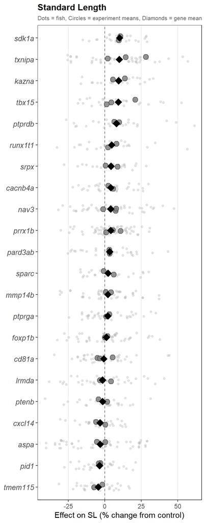

```r
p_sl <- create_forest_plot(
  plot_data = sl_plot_data,
  expt_means = sl_expt_means,
  gene_stats = sl_stats,
  title = "Standard Length",
  xlab = "Effect on SL (% change from control)",
  gene_order = gene_order_sl
)
print(p_sl)
```

```r
# Save
ggsave("forest_plot_SL.svg", p_sl, width = 4, height = 10)
ggsave("forest_plot_SL.png", p_sl, width = 4, height = 10, dpi = 200)
```

# Analysis 2: Normalised Adiposity

```r
# =============================================================================
# LMM: norm_adiposity ~ genotype + (1|experiment)
# Batch-corrected comparison of size-normalised fat content
# =============================================================================

norm_stats <- run_lmm_analysis(all_data, "norm_adiposity") %>% arrange(effect_pct)
gene_order_norm <- norm_stats$gene

# Individual % change (centered on control mean for plotting)
norm_plot_data <- calc_pct_change(all_data, "norm_adiposity")

# Experiment means (mutants only)
norm_expt_means <- norm_plot_data %>%
  filter(genotype == "mutant") %>%
  group_by(gene, experiment) %>%
  summarise(expt_mean = mean(pct_change, na.rm = TRUE), .groups = "drop")

cat("Norm adiposity analysis: LMM used for", sum(norm_stats$method == "LMM"), "genes,",
    "t-test for", sum(norm_stats$method != "LMM"), "genes\n")
```

```
## Norm adiposity analysis: LMM used for 22 genes, t-test for 0 genes
```

## Statistical Summary

```r
norm_display <- norm_stats %>%
  mutate(
    Gene = sapply(gene, format_gene_name),
    Effect = sprintf("%+.1f%%", effect_pct),
    p_raw = ifelse(p_value < 0.001, sprintf("%.2e", p_value), sprintf("%.4f", p_value)),
    p_adj_fmt = ifelse(p_adj < 0.001, sprintf("%.2e", p_adj), sprintf("%.4f", p_adj)),
    Sig = ifelse(sig, "***", "")
  ) %>%
  select(Gene, n_ctrl, n_mut, n_expts, Effect, p_raw, p_adj_fmt, Sig)

kable(norm_display,
      col.names = c("Gene", "n ctrl", "n mut", "Expts", "Effect (%)", "p (raw)", "p (BH adj)", ""),
      caption = "Normalised Adiposity (TAT/SL2): LMM with batch correction",
      escape = FALSE) %>%
  kable_styling(bootstrap_options = c("striped", "hover", "condensed"), full_width = FALSE)
```

Normalised Adiposity (TAT/SL2): LMM with batch correction

| Gene | n ctrl | n mut | Expts | Effect (%) | p (raw) | p (BH adj) |  |
| --- | --- | --- | --- | --- | --- | --- | --- |
| *sparc* | 24 | 23 | 2 | -13.2% | 0.2324 | 0.6391 |  |
| *foxp1b* | 41 | 45 | 2 | -13.2% | 0.0561 | 0.4113 |  |
| *prrx1b* | 65 | 62 | 3 | -7.8% | 0.2315 | 0.6391 |  |
| *aspa* | 64 | 55 | 2 | -5.0% | 0.7614 | 0.9282 |  |
| *ptprga* | 46 | 35 | 2 | -4.4% | 0.6888 | 0.9282 |  |
| *mmp14b* | 64 | 46 | 2 | +0.7% | 0.9701 | 0.9701 |  |
| *pid1* | 28 | 26 | 2 | +1.5% | 0.9022 | 0.9452 |  |
| *cd81a* | 38 | 41 | 3 | +2.8% | 0.8094 | 0.9282 |  |
| *cacnb4a* | 32 | 29 | 2 | +2.8% | 0.8438 | 0.9282 |  |
| *srpx* | 24 | 20 | 2 | +3.8% | 0.7606 | 0.9282 |  |
| *ptprdb* | 46 | 24 | 2 | +4.2% | 0.7471 | 0.9282 |  |
| *ptenb* | 28 | 26 | 2 | +6.3% | 0.6355 | 0.9282 |  |
| *cxcl14* | 28 | 25 | 2 | +10.5% | 0.4345 | 0.7966 |  |
| *tmem115* | 28 | 29 | 2 | +10.7% | 0.3609 | 0.7218 |  |
| *runx1t1* | 32 | 24 | 2 | +12.9% | 0.4894 | 0.8282 |  |
| *nav3* | 49 | 43 | 3 | +13.2% | 0.2900 | 0.7089 |  |
| *lrmda* | 40 | 35 | 2 | +13.4% | 0.3297 | 0.7218 |  |
| *sdk1a* | 32 | 25 | 2 | +20.8% | 0.1312 | 0.5168 |  |
| *pard3ab* | 36 | 32 | 2 | +22.0% | 0.1410 | 0.5168 |  |
| *txnipa* | 76 | 41 | 3 | +29.6% | 0.0819 | 0.4504 |  |
| *tbx15* | 38 | 27 | 3 | +29.9% | 0.0300 | 0.3295 |  |
| *kazna* | 36 | 23 | 2 | +59.1% | 4.38e-04 | 0.0096 | *** |

## Forest Plot

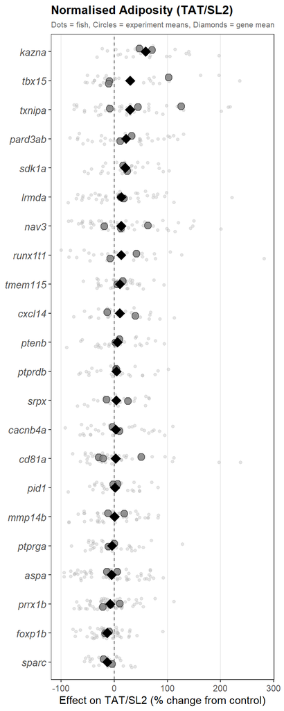

```r
p_norm <- create_forest_plot(
  plot_data = norm_plot_data,
  expt_means = norm_expt_means,
  gene_stats = norm_stats,
  title = "Normalised Adiposity (TAT/SL2)",
  xlab = "Effect on TAT/SL2 (% change from control)",
  gene_order = gene_order_norm
)
print(p_norm)
```

```r
# Save
ggsave("forest_plot_norm_adiposity.svg", p_norm, width = 4, height = 10)
ggsave("forest_plot_norm_adiposity.png", p_norm, width = 4, height = 10, dpi = 200)
```

# Analysis 3: Morphology Effect (LMM Intercept)

This is the key morphology metric from the main analysis: the LMM intercept effect representing uniform shift in Feret diameter after accounting for total adipose area and batch effects.

**Model:** `log(Feret) ~ log(AreaSum) + genotype + (1|experiment)`

This matches the v7 morphology analysis exactly.

```r
# =============================================================================
# LINEAR MIXED MODEL ANALYSIS FOR MORPHOLOGY EFFECT
# =============================================================================
#
# This analysis matches the v7 morphology Rmd exactly.
#
# MODEL: log(Feret) ~ log(AreaSum) + genotype + (1|experiment)
#
# Components:
#   - log(Feret): Mean Feret diameter per fish (log-transformed)
#   - log(AreaSum): Total adipose area per fish (log-transformed) - controls for size
#   - genotype: Fixed effect (control vs mutant) - THE EFFECT WE WANT
#   - (1|experiment): Random intercept for experiment - batch correction
#
# The genotype coefficient represents the UNIFORM SHIFT in log(Feret) for mutants
# vs controls, after accounting for:
#   1. Fish size (via log(AreaSum))
#   2. Batch differences between experiments (random effect)
#
# Positive effect = Hypertrophic (larger droplets than expected for total fat)
# Negative effect = Hyperplastic (smaller droplets than expected for total fat)
#
# The effect is converted to % change: (exp(coefficient) - 1) * 100
# =============================================================================

genes <- unique(morph_data$gene)
lmm_results_list <- list()

for (g in genes) {
  gene_data <- morph_data %>%
    filter(gene == g, !is.na(mean_feret), !is.na(total_adipose_area),
           total_adipose_area > 0, mean_feret > 0)

  if (nrow(gene_data) < 10) next

  # Need at least 2 experiments for random effect
  if (length(unique(gene_data$experiment)) < 2) next

  # Log transform
  gene_data$log_Feret <- log(gene_data$mean_feret)
  gene_data$log_AreaSum <- log(gene_data$total_adipose_area)
  gene_data$genotype <- factor(gene_data$genotype, levels = c("control", "mutant"))

  tryCatch({
    # Fit LMM (matching v7 exactly)
    model <- lmer(log_Feret ~ log_AreaSum + genotype + (1 | experiment),
                  data = gene_data, REML = TRUE)

    coefs <- summary(model)$coefficients

    # Extract the genotype effect (mutant vs control)
    intercept_effect <- as.numeric(coefs["genotypemutant", "Estimate"])
    intercept_se <- as.numeric(coefs["genotypemutant", "Std. Error"])
    intercept_t <- as.numeric(coefs["genotypemutant", "t value"])
    intercept_p <- as.numeric(coefs["genotypemutant", "Pr(>|t|)"])

    # Convert log-scale effect to percentage
    # e.g., coefficient of 0.15 -> (exp(0.15) - 1) * 100 = +16.2%
    intercept_pct <- (exp(intercept_effect) - 1) * 100

    lmm_results_list[[g]] <- data.frame(
      gene = g,
      n_ctrl = sum(gene_data$genotype == "control"),
      n_mut = sum(gene_data$genotype == "mutant"),
      n_experiments = length(unique(gene_data$experiment)),
      intercept_effect = intercept_effect,
      intercept_pct = intercept_pct,
      intercept_se = intercept_se,
      intercept_t = intercept_t,
      intercept_p = intercept_p,
      stringsAsFactors = FALSE
    )
  }, error = function(e) NULL)
}

morph_lmm_results <- do.call(rbind, lmm_results_list)
rownames(morph_lmm_results) <- NULL

# BH correction for multiple testing
morph_lmm_results$p_adj <- p.adjust(morph_lmm_results$intercept_p, method = "BH")
morph_lmm_results$sig <- morph_lmm_results$p_adj < 0.05
morph_lmm_results$direction <- ifelse(morph_lmm_results$intercept_pct > 0, "Hypertrophic", "Hyperplastic")

cat("LMM analysis completed for", nrow(morph_lmm_results), "genes\n")
```

```
## LMM analysis completed for 21 genes
```

```r
# =============================================================================
# CALCULATING INDIVIDUAL FISH RESIDUALS FOR FOREST PLOT VISUALISATION
# =============================================================================
#
# The forest plot shows three levels of data:
#   1. Small dots   = individual mutant fish (% deviation from expected Feret)
#   2. Circles      = experiment means (mean of mutant fish within each experiment)
#   3. Diamond      = gene effect (LMM intercept coefficient, batch-corrected)
#
# IMPORTANT: The LMM effect (diamond) represents the genotype coefficient from:
#   log(Feret) ~ log(AreaSum) + genotype + (1|experiment)
# This is the difference between mutant and control AFTER accounting for:
#   - The size-scaling relationship (log(AreaSum))
#   - Batch effects between experiments (random intercept)
#
# For the individual fish and experiment means to align with the LMM effect,
# we need to:
#   1. Calculate residuals from a size-correction model fitted to controls
#   2. Convert to % change: (exp(residual) - 1) * 100
#   3. CENTER on the control mean (subtract control mean from all values)
#
# Without step 3, the control mean would be non-zero (due to regression to mean),
# and the mutant datapoints would be offset from the LMM effect diamond.
# =============================================================================

morph_resid_list <- list()

for (g in unique(morph_lmm_results$gene)) {
  gene_data <- morph_data %>%
    filter(gene == g, !is.na(mean_feret), !is.na(total_adipose_area),
           total_adipose_area > 0, mean_feret > 0)

  if (nrow(gene_data) < 10) next

  gene_data$log_Feret <- log(gene_data$mean_feret)
  gene_data$log_AreaSum <- log(gene_data$total_adipose_area)
  gene_data$genotype <- factor(gene_data$genotype, levels = c("control", "mutant"))

  # Fit model to controls only to get baseline size-scaling relationship
  ctrl_data <- gene_data %>% filter(genotype == "control")

  tryCatch({
    # Step 1: Fit simple linear model on controls (pooled across experiments)
    # This captures the expected Feret diameter given total adipose area
    ctrl_model <- lm(log_Feret ~ log_AreaSum, data = ctrl_data)

    # Step 2: Calculate residuals for ALL fish (control + mutant)
    # Residual = observed log(Feret) - expected log(Feret) given size
    gene_data$predicted_log_feret <- predict(ctrl_model, newdata = gene_data)
    gene_data$log_residual <- gene_data$log_Feret - gene_data$predicted_log_feret

    # Convert log residuals to % change
    # If residual = 0.15, then % change = (exp(0.15) - 1) * 100 = +16.2%
    gene_data$raw_pct_change <- (exp(gene_data$log_residual) - 1) * 100

    # Step 3: CENTER ON CONTROL MEAN
    # The control mean won't be exactly 0 due to the nature of residuals
    # Subtracting it ensures:
    #   - Control fish are centered around 0%
    #   - Mutant fish show deviation FROM controls (matching LMM interpretation)
    #   - Experiment means bracket the overall mutant mean correctly
    ctrl_mean_pct <- mean(gene_data$raw_pct_change[gene_data$genotype == "control"])
    gene_data$pct_change <- gene_data$raw_pct_change - ctrl_mean_pct

    morph_resid_list[[g]] <- gene_data %>%
      select(gene, genotype, experiment, mean_feret, total_adipose_area, pct_change)
  }, error = function(e) NULL)
}

morph_plot_data <- bind_rows(morph_resid_list)

cat("Residuals calculated for", length(unique(morph_plot_data$gene)), "genes\n")
```

```
## Residuals calculated for 21 genes
```

```r
cat("Total fish:", nrow(morph_plot_data), "\n")
```

```
## Total fish: 1336
```

```r
# =============================================================================
# PREPARE STATS FOR PLOTTING
# =============================================================================
#
# NOTE ON LMM vs SIMPLE MEAN:
# The diamond shows the LMM effect (batch-corrected), while the experiment
# circles show simple means within each experiment. These may differ slightly
# because the LMM weights experiments by precision and accounts for batch effects.
# The individual fish dots and experiment circles should be internally consistent
# (circles bracket the overall simple mean), while the diamond may be slightly
# offset due to batch correction.
# =============================================================================

morph_stats <- morph_lmm_results %>%
  select(gene, n_ctrl, n_mut, effect_pct = intercept_pct, p_value = intercept_p, p_adj, sig, direction) %>%
  arrange(effect_pct)

gene_order_morph <- morph_stats$gene

# Experiment means (mutants only) - these are SIMPLE means, not LMM-adjusted
morph_expt_means <- morph_plot_data %>%
  filter(genotype == "mutant") %>%
  group_by(gene, experiment) %>%
  summarise(expt_mean = mean(pct_change, na.rm = TRUE), .groups = "drop")
```

## Statistical Summary

```r
morph_display <- morph_stats %>%
  mutate(
    Gene = sapply(gene, format_gene_name),
    Effect = sprintf("%+.2f%%", effect_pct),
    p_raw = ifelse(p_value < 0.001, sprintf("%.2e", p_value), sprintf("%.4f", p_value)),
    p_adj_fmt = ifelse(p_adj < 0.001, sprintf("%.2e", p_adj), sprintf("%.4f", p_adj)),
    Sig = ifelse(sig, "***", "")
  ) %>%
  select(Gene, n_ctrl, n_mut, Effect, direction, p_raw, p_adj_fmt, Sig)

kable(morph_display,
      col.names = c("Gene", "n ctrl", "n mut", "Effect (%)", "Direction", "p (raw)", "p (BH adj)", ""),
      caption = "Morphology Effect (LMM Intercept): Uniform shift in droplet size (batch-corrected)",
      escape = FALSE) %>%
  kable_styling(bootstrap_options = c("striped", "hover", "condensed"), full_width = FALSE)
```

Morphology Effect (LMM Intercept): Uniform shift in droplet size (batch-corrected)

| Gene | n ctrl | n mut | Effect (%) | Direction | p (raw) | p (BH adj) |  |
| --- | --- | --- | --- | --- | --- | --- | --- |
| *cxcl14* | 27 | 24 | -8.70% | Hyperplastic | 0.0828 | 0.3476 |  |
| *ptenb* | 27 | 25 | -7.88% | Hyperplastic | 0.1370 | 0.4109 |  |
| *sparc* | 24 | 23 | -7.12% | Hyperplastic | 0.4208 | 0.7364 |  |
| *pid1* | 27 | 26 | -6.50% | Hyperplastic | 0.2152 | 0.5649 |  |
| *nav3* | 49 | 42 | -6.06% | Hyperplastic | 0.2785 | 0.6497 |  |
| *prrx1b* | 65 | 60 | -5.88% | Hyperplastic | 0.1024 | 0.3584 |  |
| *cd81a* | 24 | 26 | -4.99% | Hyperplastic | 0.5419 | 0.7587 |  |
| *kazna* | 36 | 23 | -4.67% | Hyperplastic | 0.5013 | 0.7587 |  |
| *tmem115* | 27 | 29 | -3.77% | Hyperplastic | 0.5081 | 0.7587 |  |
| *lrmda* | 27 | 22 | -2.69% | Hyperplastic | 0.6185 | 0.7777 |  |
| *ptprga* | 35 | 35 | -1.64% | Hyperplastic | 0.7658 | 0.8041 |  |
| *srpx* | 36 | 20 | -0.89% | Hyperplastic | 0.8356 | 0.8356 |  |
| *pard3ab* | 36 | 32 | +2.11% | Hypertrophic | 0.7283 | 0.8041 |  |
| *cacnb4a* | 29 | 27 | +2.58% | Hypertrophic | 0.7213 | 0.8041 |  |
| *tbx15* | 37 | 26 | +3.74% | Hypertrophic | 0.6296 | 0.7777 |  |
| *runx1t1* | 29 | 22 | +7.57% | Hypertrophic | 0.4082 | 0.7364 |  |
| *sdk1a* | 29 | 25 | +7.59% | Hypertrophic | 0.3306 | 0.6942 |  |
| *mmp14b* | 34 | 30 | +15.80% | Hypertrophic | 1.84e-05 | 1.93e-04 | *** |
| *foxp1b* | 42 | 45 | +17.01% | Hypertrophic | 0.0070 | 0.0490 | *** |
| *ptprdb* | 35 | 24 | +18.50% | Hypertrophic | 0.0165 | 0.0867 |  |
| *txnipa* | 45 | 30 | +19.89% | Hypertrophic | 7.77e-06 | 1.63e-04 | *** |

## Forest Plot

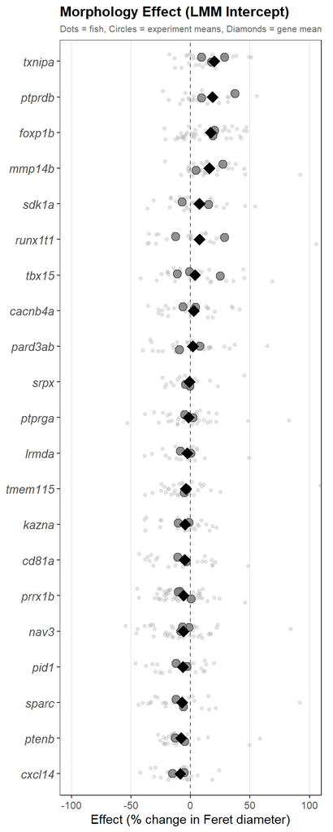

```r
p_morph <- create_forest_plot(
  plot_data = morph_plot_data,
  expt_means = morph_expt_means,
  gene_stats = morph_stats,
  title = "Morphology Effect (LMM Intercept)",
  xlab = "Effect (% change in Feret diameter)",
  gene_order = gene_order_morph
) +
  coord_cartesian(xlim = c(-100, 100))  # Restrict x-axis to ±100%

print(p_morph)
```

```r
# Save
ggsave("forest_plot_morphology_effect.svg", p_morph, width = 4, height = 10)
ggsave("forest_plot_morphology_effect.png", p_morph, width = 4, height = 10, dpi = 200)
```

# Analysis 4: Droplet Count

```r
# =============================================================================
# LMM: droplet_count ~ genotype + (1|experiment)
# Batch-corrected comparison of lipid droplet number
# Note: NOT size-corrected (larger fish may have more droplets)
# =============================================================================

droplet_n_stats <- run_lmm_analysis(all_data, "droplet_count") %>% arrange(effect_pct)
gene_order_droplet_n <- droplet_n_stats$gene

# Individual % change (centered on control mean for plotting)
droplet_n_plot_data <- calc_pct_change(all_data, "droplet_count")

# Experiment means (mutants only)
droplet_n_expt_means <- droplet_n_plot_data %>%
  filter(genotype == "mutant") %>%
  group_by(gene, experiment) %>%
  summarise(expt_mean = mean(pct_change, na.rm = TRUE), .groups = "drop")

cat("Droplet count analysis: LMM used for", sum(droplet_n_stats$method == "LMM"), "genes,",
    "t-test for", sum(droplet_n_stats$method != "LMM"), "genes\n")
```

```
## Droplet count analysis: LMM used for 21 genes, t-test for 1 genes
```

## Statistical Summary

```r
droplet_n_display <- droplet_n_stats %>%
  mutate(
    Gene = sapply(gene, format_gene_name),
    Effect = sprintf("%+.1f%%", effect_pct),
    p_raw = ifelse(p_value < 0.001, sprintf("%.2e", p_value), sprintf("%.4f", p_value)),
    p_adj_fmt = ifelse(p_adj < 0.001, sprintf("%.2e", p_adj), sprintf("%.4f", p_adj)),
    Sig = ifelse(sig, "***", "")
  ) %>%
  select(Gene, n_ctrl, n_mut, n_expts, Effect, p_raw, p_adj_fmt, Sig)

kable(droplet_n_display,
      col.names = c("Gene", "n ctrl", "n mut", "Expts", "Effect (%)", "p (raw)", "p (BH adj)", ""),
      caption = "Droplet Count: LMM with batch correction",
      escape = FALSE) %>%
  kable_styling(bootstrap_options = c("striped", "hover", "condensed"), full_width = FALSE)
```

Droplet Count: LMM with batch correction

| Gene | n ctrl | n mut | Expts | Effect (%) | p (raw) | p (BH adj) |  |
| --- | --- | --- | --- | --- | --- | --- | --- |
| *pid1* | 27 | 26 | 2 | -10.1% | 0.5634 | 0.8263 |  |
| *aspa* | 18 | 17 | 1 | -6.4% | 0.8023 | 0.9129 |  |
| *mmp14b* | 34 | 30 | 2 | +1.9% | 0.9129 | 0.9129 |  |
| *lrmda* | 27 | 22 | 2 | +2.9% | 0.8886 | 0.9129 |  |
| *cd81a* | 24 | 26 | 2 | +5.3% | 0.8504 | 0.9129 |  |
| *cxcl14* | 27 | 24 | 2 | +5.9% | 0.7219 | 0.8823 |  |
| *tmem115* | 27 | 29 | 2 | +6.6% | 0.6717 | 0.8823 |  |
| *cacnb4a* | 29 | 27 | 2 | +10.0% | 0.6848 | 0.8823 |  |
| *ptprdb* | 35 | 24 | 2 | +14.4% | 0.4658 | 0.7498 |  |
| *ptprga* | 35 | 35 | 2 | +19.1% | 0.3143 | 0.5762 |  |
| *sparc* | 24 | 23 | 2 | +23.0% | 0.4772 | 0.7498 |  |
| *txnipa* | 34 | 24 | 2 | +24.1% | 0.2356 | 0.5183 |  |
| *foxp1b* | 42 | 45 | 2 | +25.3% | 0.0700 | 0.2769 |  |
| *prrx1b* | 65 | 60 | 3 | +26.3% | 0.0369 | 0.2707 |  |
| *pard3ab* | 36 | 32 | 2 | +30.5% | 0.2264 | 0.5183 |  |
| *ptenb* | 27 | 25 | 2 | +31.3% | 0.0755 | 0.2769 |  |
| *tbx15* | 24 | 17 | 2 | +34.6% | 0.2664 | 0.5327 |  |
| *runx1t1* | 29 | 22 | 2 | +35.7% | 0.2291 | 0.5183 |  |
| *nav3* | 36 | 28 | 2 | +43.2% | 0.1030 | 0.3236 |  |
| *sdk1a* | 29 | 25 | 2 | +50.0% | 0.0362 | 0.2707 |  |
| *srpx* | 26 | 20 | 2 | +54.7% | 0.0726 | 0.2769 |  |
| *kazna* | 36 | 23 | 2 | +89.6% | 0.0016 | 0.0349 | *** |

## Forest Plot

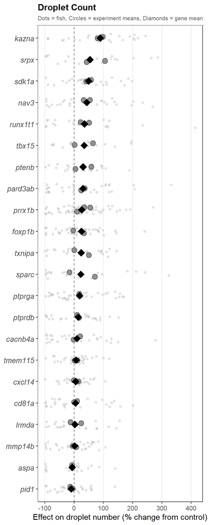

```r
p_droplet_n <- create_forest_plot(
  plot_data = droplet_n_plot_data,
  expt_means = droplet_n_expt_means,
  gene_stats = droplet_n_stats,
  title = "Droplet Count",
  xlab = "Effect on droplet number (% change from control)",
  gene_order = gene_order_droplet_n
)
print(p_droplet_n)
```

```r
# Save
ggsave("forest_plot_droplet_count.svg", p_droplet_n, width = 4, height = 10)
ggsave("forest_plot_droplet_count.png", p_droplet_n, width = 4, height = 10, dpi = 200)
```

# Analysis 5: Mean Droplet Area

```r
# =============================================================================
# LMM: mean_droplet_area ~ genotype + (1|experiment)
# Batch-corrected comparison of lipid droplet size
# Note: NOT size-corrected (larger fish may have larger droplets)
# For size-corrected morphology, see Analysis 3 (LMM Intercept)
# =============================================================================

droplet_area_stats <- run_lmm_analysis(all_data, "mean_droplet_area") %>% arrange(effect_pct)
gene_order_droplet_area <- droplet_area_stats$gene

# Individual % change (centered on control mean for plotting)
droplet_area_plot_data <- calc_pct_change(all_data, "mean_droplet_area")

# Experiment means (mutants only)
droplet_area_expt_means <- droplet_area_plot_data %>%
  filter(genotype == "mutant") %>%
  group_by(gene, experiment) %>%
  summarise(expt_mean = mean(pct_change, na.rm = TRUE), .groups = "drop")

cat("Droplet area analysis: LMM used for", sum(droplet_area_stats$method == "LMM"), "genes,",
    "t-test for", sum(droplet_area_stats$method != "LMM"), "genes\n")
```

```
## Droplet area analysis: LMM used for 21 genes, t-test for 1 genes
```

## Statistical Summary

```r
droplet_area_display <- droplet_area_stats %>%
  mutate(
    Gene = sapply(gene, format_gene_name),
    Effect = sprintf("%+.1f%%", effect_pct),
    p_raw = ifelse(p_value < 0.001, sprintf("%.2e", p_value), sprintf("%.4f", p_value)),
    p_adj_fmt = ifelse(p_adj < 0.001, sprintf("%.2e", p_adj), sprintf("%.4f", p_adj)),
    Sig = ifelse(sig, "***", "")
  ) %>%
  select(Gene, n_ctrl, n_mut, n_expts, Effect, p_raw, p_adj_fmt, Sig)

kable(droplet_area_display,
      col.names = c("Gene", "n ctrl", "n mut", "Expts", "Effect (%)", "p (raw)", "p (BH adj)", ""),
      caption = "Mean Droplet Area: LMM with batch correction",
      escape = FALSE) %>%
  kable_styling(bootstrap_options = c("striped", "hover", "condensed"), full_width = FALSE)
```

Mean Droplet Area: LMM with batch correction

| Gene | n ctrl | n mut | Expts | Effect (%) | p (raw) | p (BH adj) |  |
| --- | --- | --- | --- | --- | --- | --- | --- |
| *ptenb* | 27 | 25 | 2 | -18.4% | 0.2513 | 0.5528 |  |
| *pid1* | 27 | 26 | 2 | -14.8% | 0.3373 | 0.6639 |  |
| *cxcl14* | 27 | 24 | 2 | -10.6% | 0.4896 | 0.6732 |  |
| *tmem115* | 27 | 29 | 2 | -10.4% | 0.4860 | 0.6732 |  |
| *sparc* | 24 | 23 | 2 | -2.1% | 0.9179 | 0.9595 |  |
| *prrx1b* | 65 | 60 | 3 | +0.5% | 0.9595 | 0.9595 |  |
| *srpx* | 36 | 20 | 2 | +2.4% | 0.8960 | 0.9595 |  |
| *ptprga* | 35 | 35 | 2 | +3.8% | 0.8490 | 0.9595 |  |
| *lrmda* | 27 | 22 | 2 | +8.1% | 0.6438 | 0.7868 |  |
| *nav3* | 49 | 42 | 3 | +13.3% | 0.4613 | 0.6732 |  |
| *cd81a* | 24 | 26 | 2 | +13.4% | 0.5479 | 0.7090 |  |
| *pard3ab* | 36 | 32 | 2 | +20.1% | 0.3621 | 0.6639 |  |
| *cacnb4a* | 29 | 27 | 2 | +24.5% | 0.4064 | 0.6732 |  |
| *runx1t1* | 29 | 22 | 2 | +37.7% | 0.1906 | 0.4659 |  |
| *aspa* | 18 | 17 | 1 | +42.5% | 0.1799 | 0.4659 |  |
| *mmp14b* | 34 | 30 | 2 | +46.3% | 0.0272 | 0.1025 |  |
| *sdk1a* | 29 | 25 | 2 | +55.7% | 0.0280 | 0.1025 |  |
| *ptprdb* | 35 | 24 | 2 | +55.8% | 0.0395 | 0.1242 |  |
| *kazna* | 36 | 23 | 2 | +56.5% | 0.0255 | 0.1025 |  |
| *foxp1b* | 42 | 45 | 2 | +72.8% | 6.49e-04 | 0.0059 | *** |
| *txnipa* | 45 | 30 | 3 | +73.3% | 2.07e-04 | 0.0046 | *** |
| *tbx15* | 37 | 26 | 3 | +92.2% | 8.07e-04 | 0.0059 | *** |

## Forest Plot

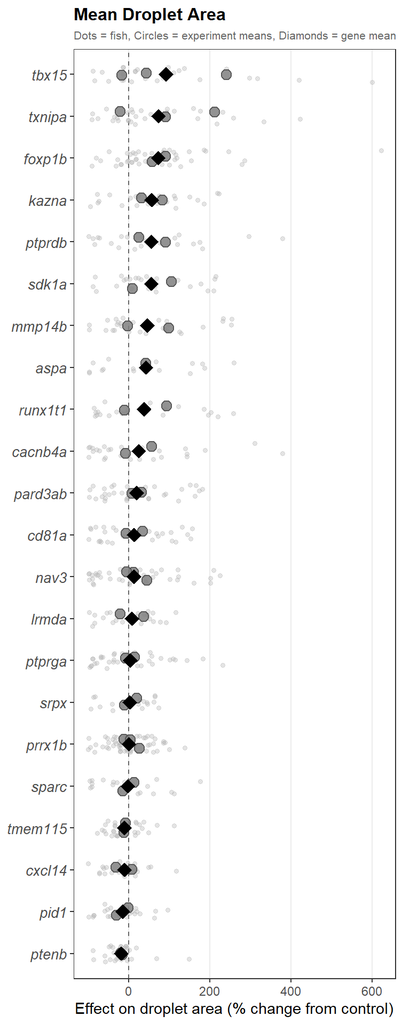

```r
p_droplet_area <- create_forest_plot(
  plot_data = droplet_area_plot_data,
  expt_means = droplet_area_expt_means,
  gene_stats = droplet_area_stats,
  title = "Mean Droplet Area",
  xlab = "Effect on droplet area (% change from control)",
  gene_order = gene_order_droplet_area
)
print(p_droplet_area)
```

```r
# Save
ggsave("forest_plot_droplet_area.svg", p_droplet_area, width = 4, height = 10)
ggsave("forest_plot_droplet_area.png", p_droplet_area, width = 4, height = 10, dpi = 200)
```